# Summary_of_Results

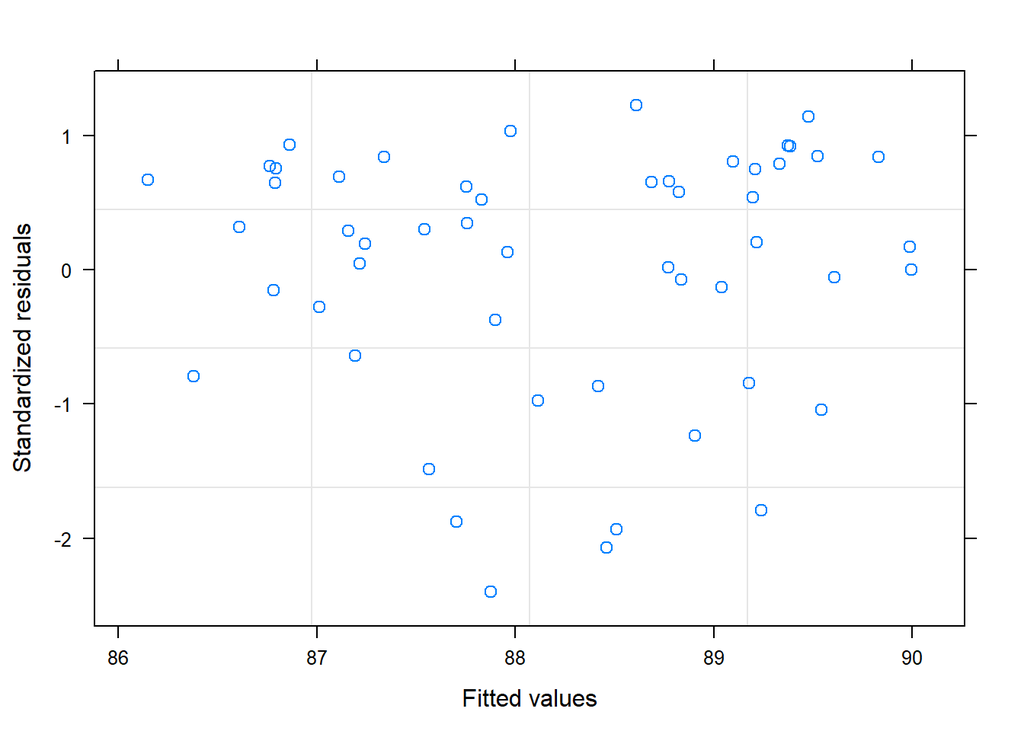

Model 3: Add daily mean PM2.5

```
## Generalized least squares fit by REML
##   Model: Avgmilk ~ DATE + THI + FOOTHILLS_DAILYMAXO3 + PM2.5_avg
##   Data: dairy_data2
##        AIC    BIC    logLik
##   220.0616 233.16 -103.0308
##
## Correlation Structure: AR(1)
##  Formula: ~1
##  Parameter estimate(s):
##       Phi
## 0.5839471
##
## Coefficients:
##                          Value Std.Error    t-value p-value
## (Intercept)          -422.7695  580.7996 -0.7279094  0.4702
## DATE                    0.0282    0.0322  0.8758381  0.3855
## THI                     0.0597    0.0325  1.8380908  0.0722
## FOOTHILLS_DAILYMAXO3   -0.0147    0.0313 -0.4699386  0.6405
## PM2.5_avg              -0.1662    0.0992 -1.6749973  0.1004
##
##  Correlation:
##                      (Intr) DATE   THI    FOOTHI
## DATE                 -1.000
## THI                   0.402 -0.403
## FOOTHILLS_DAILYMAXO3 -0.093  0.091 -0.550
## PM2.5_avg            -0.291  0.291 -0.270  0.018
##
## Standardized residuals:
##        Min         Q1        Med         Q3        Max
## -1.9586533 -0.6010510  0.2266610  0.7447238  1.1773811
##
## Residual standard error: 1.830334
## Degrees of freedom: 53 total; 48 residual
```

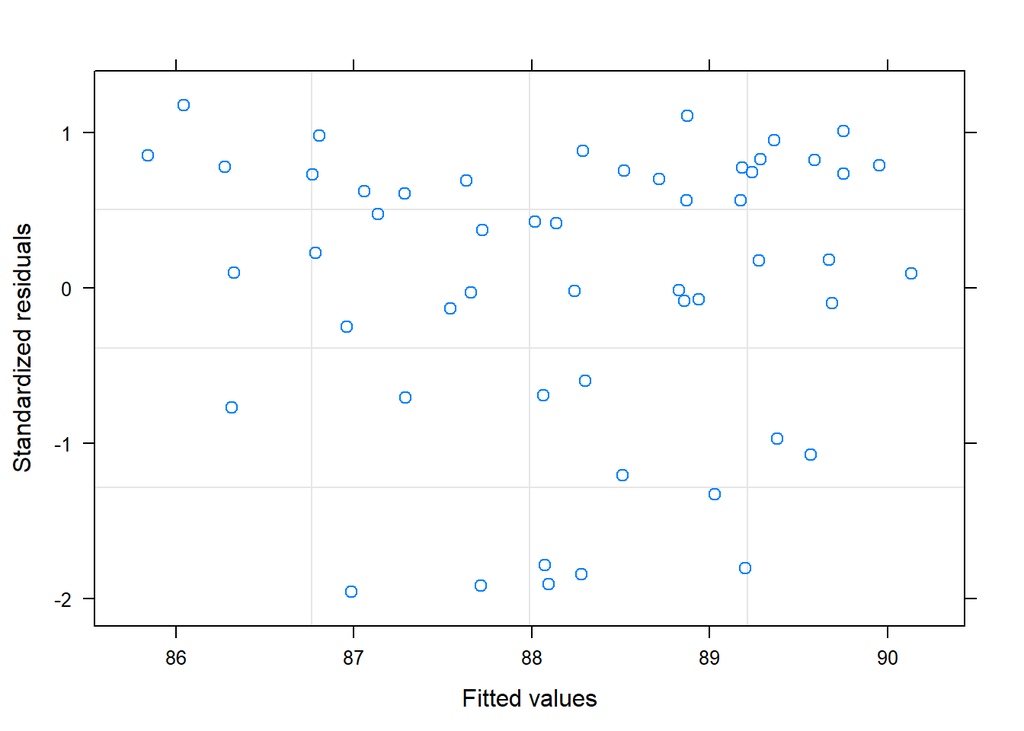

Model 4: Swap for daily max pm2.5

```
## Generalized least squares fit by REML
##   Model: Avgmilk ~ DATE + THI + FOOTHILLS_DAILYMAXO3 + PM2.5_max
##   Data: dairy_data2
##        AIC      BIC    logLik
##   222.8778 235.9762 -104.4389
##
## Correlation Structure: AR(1)
##  Formula: ~1
##  Parameter estimate(s):
##       Phi
## 0.5956732
##
## Coefficients:
##                          Value Std.Error    t-value p-value
## (Intercept)          -587.7629  585.3666 -1.0040937  0.3204
## DATE                    0.0374    0.0325  1.1507138  0.2556
## THI                     0.0464    0.0318  1.4614544  0.1504
## FOOTHILLS_DAILYMAXO3   -0.0060    0.0321 -0.1874279  0.8521
## PM2.5_max              -0.0568    0.0471 -1.2063661  0.2336
##
##  Correlation:
##                      (Intr) DATE   THI    FOOTHI
## DATE                 -1.000
## THI                   0.349 -0.350
## FOOTHILLS_DAILYMAXO3 -0.055  0.054 -0.543
## PM2.5_max            -0.179  0.179 -0.063 -0.166
##
## Standardized residuals:
##        Min         Q1        Med         Q3        Max
## -2.2074074 -0.4789962  0.2448579  0.7064663  1.1692942
##
## Residual standard error: 1.876619
## Degrees of freedom: 53 total; 48 residual
```

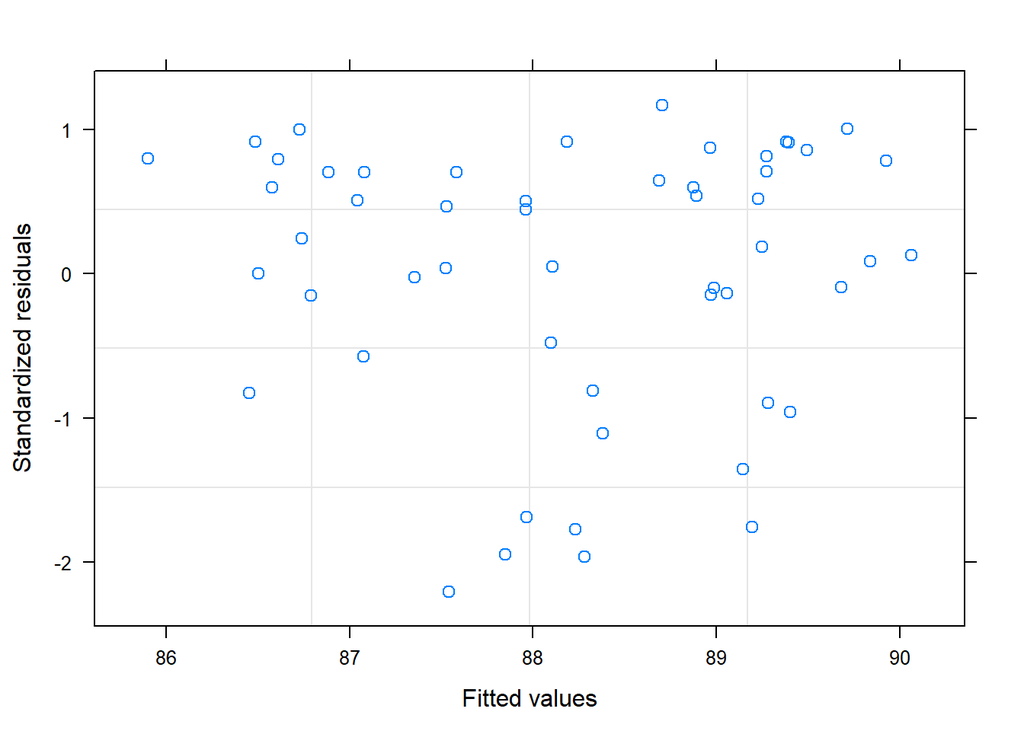

## Regression Analyses for Somatic Cell Counts

We used two different modeling approaches to estimate the relationship between daily somatic cell counts and the environmental predictors: linear regression and generalized least squares with an autrocorrelation (AR1) structure.

#### Linear regression results

Model 0: Just date

```
##
## Call:
## lm(formula = SCC_avg ~ DATE, data = dairy_data)
##
## Residuals:
##      Min       1Q   Median       3Q      Max
## -16.6227  -4.8492  -0.7987   5.0428  17.4747
##
## Coefficients:
##                Estimate  Std. Error t value Pr(>|t|)
## (Intercept) -1922.53620  1134.76633  -1.694   0.0955 .
## DATE            0.11150     0.06288   1.773   0.0813 .
## ---
## Signif. codes:  0 '***' 0.001 '**' 0.01 '*' 0.05 '.' 0.1 ' ' 1
##
## Residual standard error: 8.647 on 59 degrees of freedom
## Multiple R-squared:  0.0506, Adjusted R-squared:  0.03451
## F-statistic: 3.145 on 1 and 59 DF,  p-value: 0.08134
```

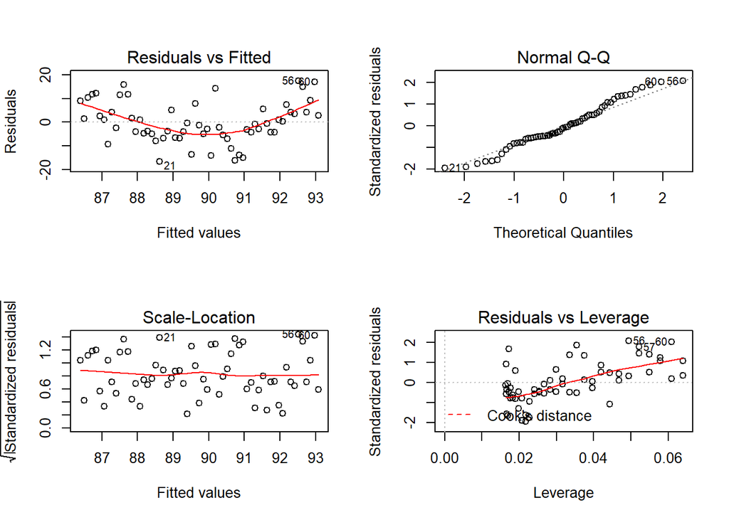

Model 1: Add THI

```
##
## Call:
## lm(formula = SCC_avg ~ THI, data = dairy_data)
##
## Residuals:
##     Min      1Q  Median      3Q     Max
## -15.593  -5.605  -1.733   7.351  17.211
##
## Coefficients:
##             Estimate Std. Error t value             Pr(>|t|)
## (Intercept) 76.97351    4.90565  15.691 < 0.0000000000000002 ***
## THI          0.21879    0.08114   2.697              0.00928 **
## ---
## Signif. codes:  0 '***' 0.001 '**' 0.01 '*' 0.05 '.' 0.1 ' ' 1
##
## Residual standard error: 8.472 on 55 degrees of freedom
##   (4 observations deleted due to missingness)
## Multiple R-squared:  0.1168, Adjusted R-squared:  0.1007
## F-statistic: 7.271 on 1 and 55 DF,  p-value: 0.009281
```

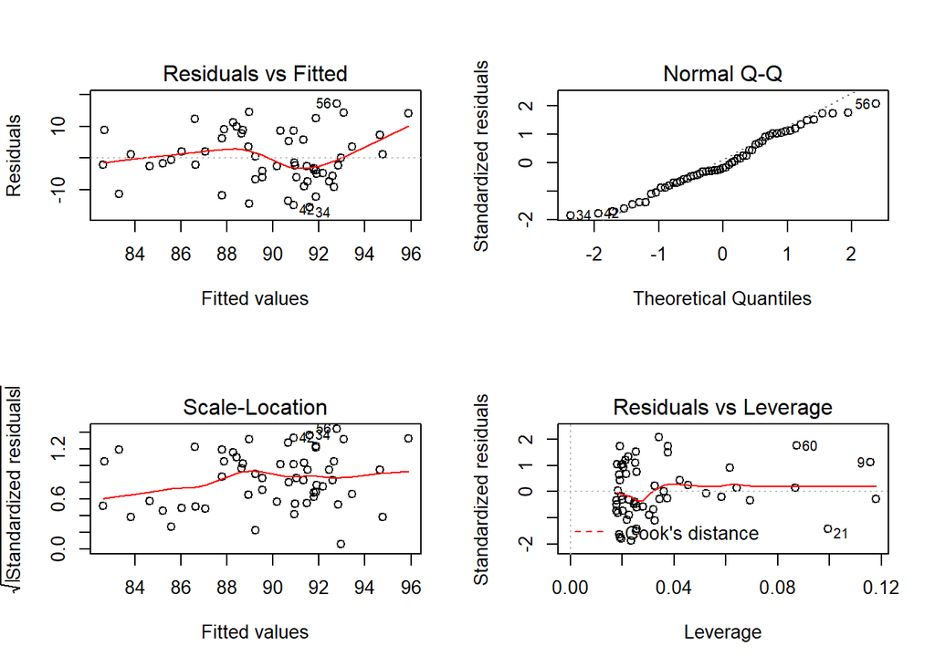

Model 2: Add ozone

```
##
## Call:
## lm(formula = SCC_avg ~ THI + FOOTHILLS_DAILYMAXO3, data = dairy_data)
##
## Residuals:
##      Min       1Q   Median       3Q      Max
## -14.6927  -4.8568  -0.8151   6.6817  19.5703
##
## Coefficients:
##                      Estimate Std. Error t value            Pr(>|t|)
## (Intercept)          76.95534    6.22622  12.360 <0.0000000000000002 ***
## THI                   0.03088    0.12864   0.240               0.811
## FOOTHILLS_DAILYMAXO3  0.19383    0.16244   1.193               0.238
## ---
## Signif. codes:  0 '***' 0.001 '**' 0.01 '*' 0.05 '.' 0.1 ' ' 1
##
## Residual standard error: 8.384 on 50 degrees of freedom
##   (8 observations deleted due to missingness)
## Multiple R-squared:  0.07218,    Adjusted R-squared:  0.03507
## F-statistic: 1.945 on 2 and 50 DF,  p-value: 0.1537
```

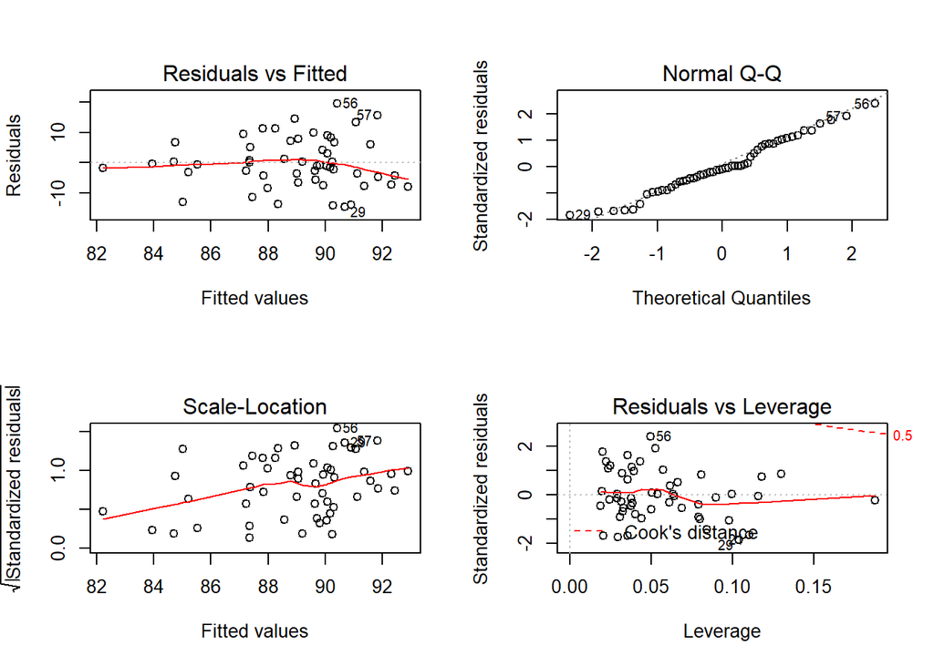

Model 3: Add daily mean PM2.5

```
##
## Call:
## lm(formula = SCC_avg ~ THI + FOOTHILLS_DAILYMAXO3 + PM2.5_avg,
##     data = dairy_data)
##
## Residuals:
##      Min       1Q   Median       3Q      Max
## -14.6221  -5.3100  -0.9138   6.2810  20.2438
##
## Coefficients:
##                      Estimate Std. Error t value             Pr(>|t|)
## (Intercept)          75.91974    6.39984  11.863 0.000000000000000516 ***
## THI                   0.05019    0.13167   0.381                0.705
## FOOTHILLS_DAILYMAXO3  0.15962    0.16924   0.943                0.350
## PM2.5_avg             0.40459    0.53295   0.759                0.451
## ---
## Signif. codes:  0 '***' 0.001 '**' 0.01 '*' 0.05 '.' 0.1 ' ' 1
##
## Residual standard error: 8.42 on 49 degrees of freedom
##   (8 observations deleted due to missingness)
## Multiple R-squared:  0.08297,    Adjusted R-squared:  0.02682
## F-statistic: 1.478 on 3 and 49 DF,  p-value: 0.2321
```

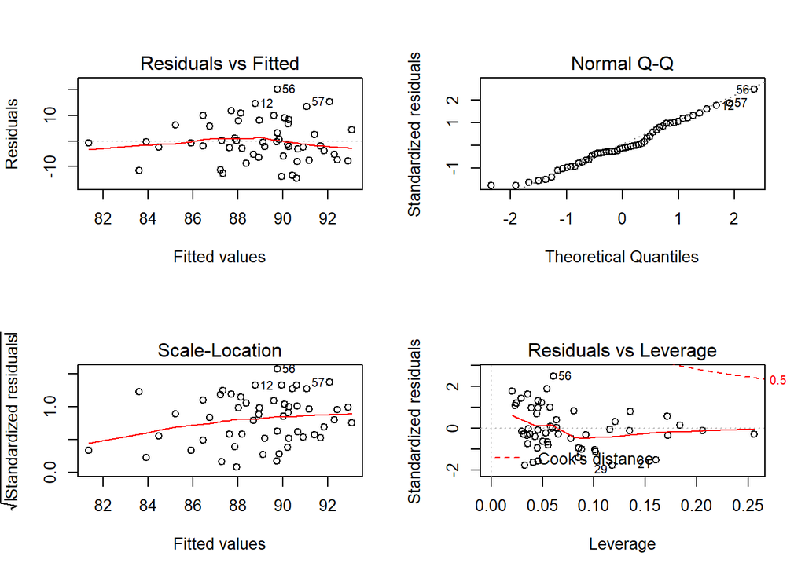

Model 4: Swap for daily max pm2.5

```
##
## Call:
## lm(formula = SCC_avg ~ THI + FOOTHILLS_DAILYMAXO3 + PM2.5_max,
##     data = dairy_data)
##
## Residuals:
##     Min      1Q  Median      3Q     Max
## -14.019  -5.873  -1.175   6.082  20.170
##
## Coefficients:
##                      Estimate Std. Error t value            Pr(>|t|)
## (Intercept)          74.93118    6.47069  11.580 0.00000000000000124 ***
## THI                   0.07498    0.13428   0.558               0.579
## FOOTHILLS_DAILYMAXO3  0.13761    0.16970   0.811               0.421
## PM2.5_max             0.29950    0.26849   1.116               0.270
## ---
## Signif. codes:  0 '***' 0.001 '**' 0.01 '*' 0.05 '.' 0.1 ' ' 1
##
## Residual standard error: 8.364 on 49 degrees of freedom
##   (8 observations deleted due to missingness)
## Multiple R-squared:  0.09516,    Adjusted R-squared:  0.03976
## F-statistic: 1.718 on 3 and 49 DF,  p-value: 0.1756
```

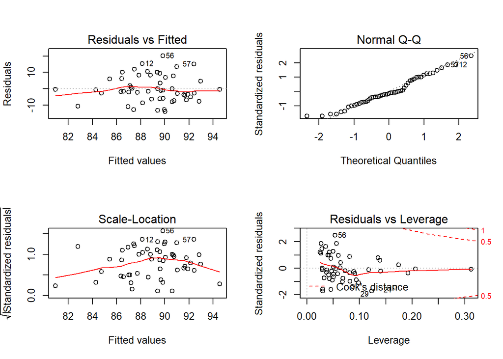

#### Generalized least squares regression results

Model 0: Just date

```
## Generalized least squares fit by REML
##   Model: SCC_avg ~ DATE
##   Data: dairy_data2
##        AIC      BIC    logLik
##   368.6565 376.3838 -180.3282
##
## Correlation Structure: AR(1)
##  Formula: ~1
##  Parameter estimate(s):
##       Phi
## 0.5718649
##
## Coefficients:
##                  Value Std.Error   t-value p-value
## (Intercept) -1469.6187 2530.5400 -0.580753  0.5640
## DATE            0.0864    0.1402  0.616086  0.5406
##
##  Correlation:
##      (Intr)
## DATE -1
##
## Standardized residuals:
##        Min         Q1        Med         Q3        Max
## -1.8245326 -0.5444105 -0.2518828  0.5496600  2.0112191
##
## Residual standard error: 9.118493
## Degrees of freedom: 53 total; 51 residual
```

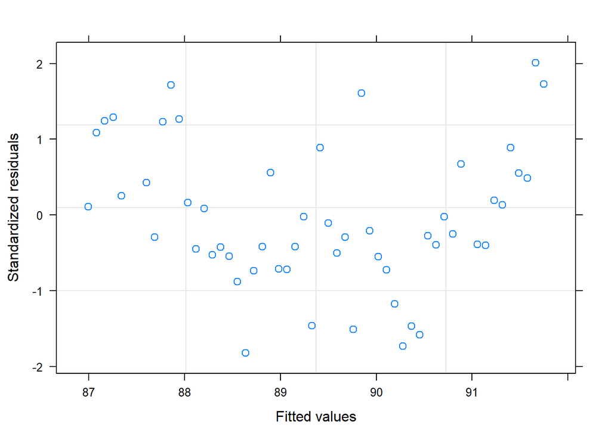

Model 1: Add THI

```
## Generalized least squares fit by REML
##   Model: SCC_avg ~ DATE + THI
##   Data: dairy_data2
##        AIC     BIC   logLik
##   371.6779 381.238 -180.839
##
## Correlation Structure: AR(1)
##  Formula: ~1
##  Parameter estimate(s):
##       Phi
## 0.5644189
##
## Coefficients:
##                 Value Std.Error    t-value p-value
## (Intercept) -325.7827 2682.4120 -0.1214514  0.9038
## DATE           0.0226    0.1488  0.1515596  0.8801
## THI            0.1436    0.1288  1.1149327  0.2702
##
##  Correlation:
##      (Intr) DATE
## DATE -1.000
## THI   0.376 -0.378
##
## Standardized residuals:
##        Min         Q1        Med         Q3        Max
## -1.6457521 -0.6026387 -0.2084317  0.6658041  1.9751300
##
## Residual standard error: 9.035982
## Degrees of freedom: 53 total; 50 residual
```

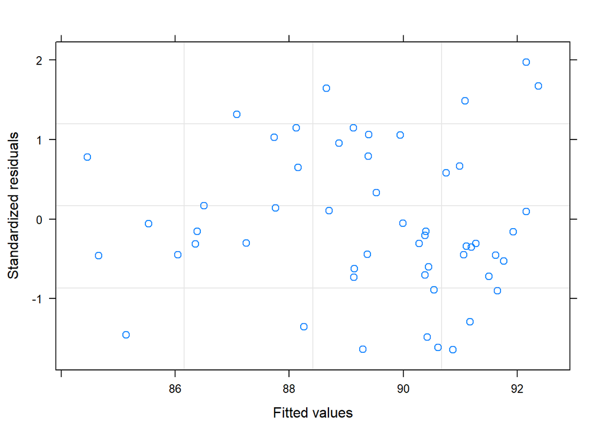

Model 2: Add ozone

```
## Generalized least squares fit by REML
##   Model: SCC_avg ~ DATE + THI + FOOTHILLS_DAILYMAXO3
##   Data: dairy_data2
##        AIC      BIC   logLik
##   372.3519 383.7028 -180.176
##
## Correlation Structure: AR(1)
##  Formula: ~1
##  Parameter estimate(s):
##      Phi
## 0.587638
##
## Coefficients:
##                          Value Std.Error    t-value p-value
## (Intercept)          -848.9361 2751.0525 -0.3085859  0.7589
## DATE                    0.0512    0.1526  0.3357207  0.7385
## THI                    -0.0154    0.1538 -0.1002672  0.9205
## FOOTHILLS_DAILYMAXO3    0.2801    0.1539  1.8198187  0.0749
##
##  Correlation:
##                      (Intr) DATE   THI
## DATE                 -1.000
## THI                   0.349 -0.350
## FOOTHILLS_DAILYMAXO3 -0.090  0.089 -0.565
##
## Standardized residuals:
##         Min          Q1         Med          Q3         Max
## -1.80184764 -0.66697291 -0.06153584  0.66023116  2.00405306
##
## Residual standard error: 9.030773
## Degrees of freedom: 53 total; 49 residual
```

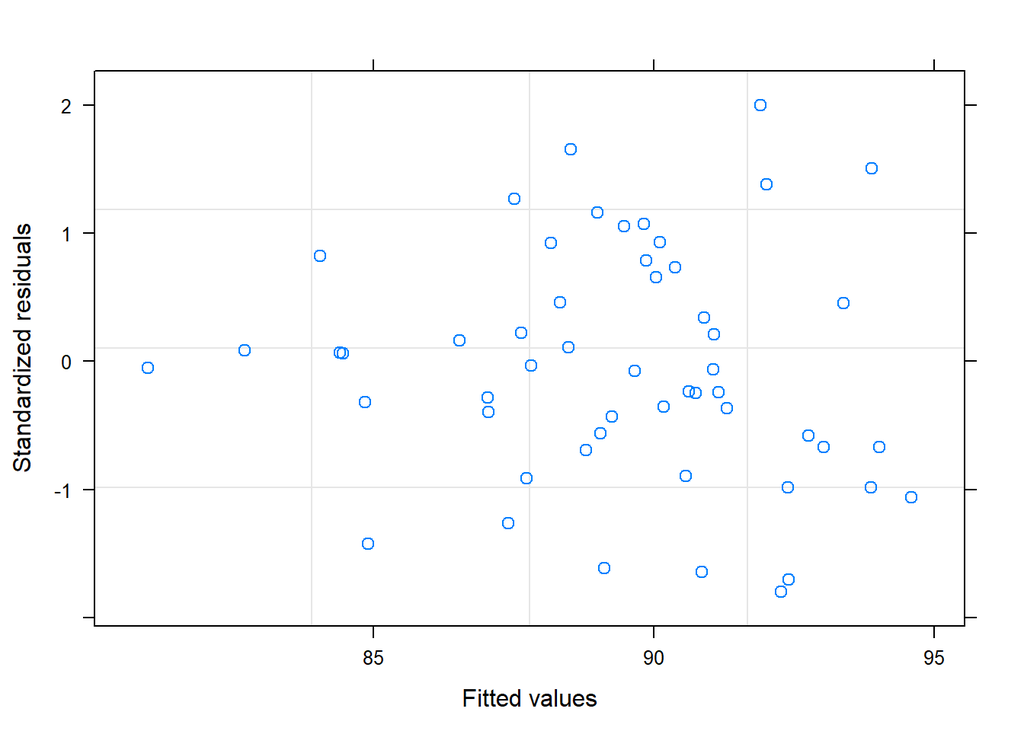

Model 3: Add daily mean PM2.5

```
## Generalized least squares fit by REML
##   Model: SCC_avg ~ DATE + THI + FOOTHILLS_DAILYMAXO3 + PM2.5_avg
##   Data: dairy_data2
##        AIC      BIC    logLik
##   373.7053 386.8037 -179.8527
##
## Correlation Structure: AR(1)
##  Formula: ~1
##  Parameter estimate(s):
##      Phi
## 0.578377
##
## Coefficients:
##                           Value Std.Error    t-value p-value
## (Intercept)          -1232.5351 2850.9817 -0.4323196  0.6674
## DATE                     0.0725    0.1581  0.4584395  0.6487
## THI                     -0.0362    0.1609 -0.2249025  0.8230
## FOOTHILLS_DAILYMAXO3     0.2806    0.1554  1.8058265  0.0772
## PM2.5_avg                0.2395    0.4924  0.4864631  0.6289
##
##  Correlation:
##                      (Intr) DATE   THI    FOOTHI
## DATE                 -1.000
## THI                   0.405 -0.406
## FOOTHILLS_DAILYMAXO3 -0.094  0.093 -0.551
## PM2.5_avg            -0.294  0.293 -0.269  0.017
##
## Standardized residuals:
##         Min          Q1         Med          Q3         Max
## -1.79936149 -0.63722538 -0.04360628  0.67806129  2.03437054
##
## Residual standard error: 9.022306
## Degrees of freedom: 53 total; 48 residual
```

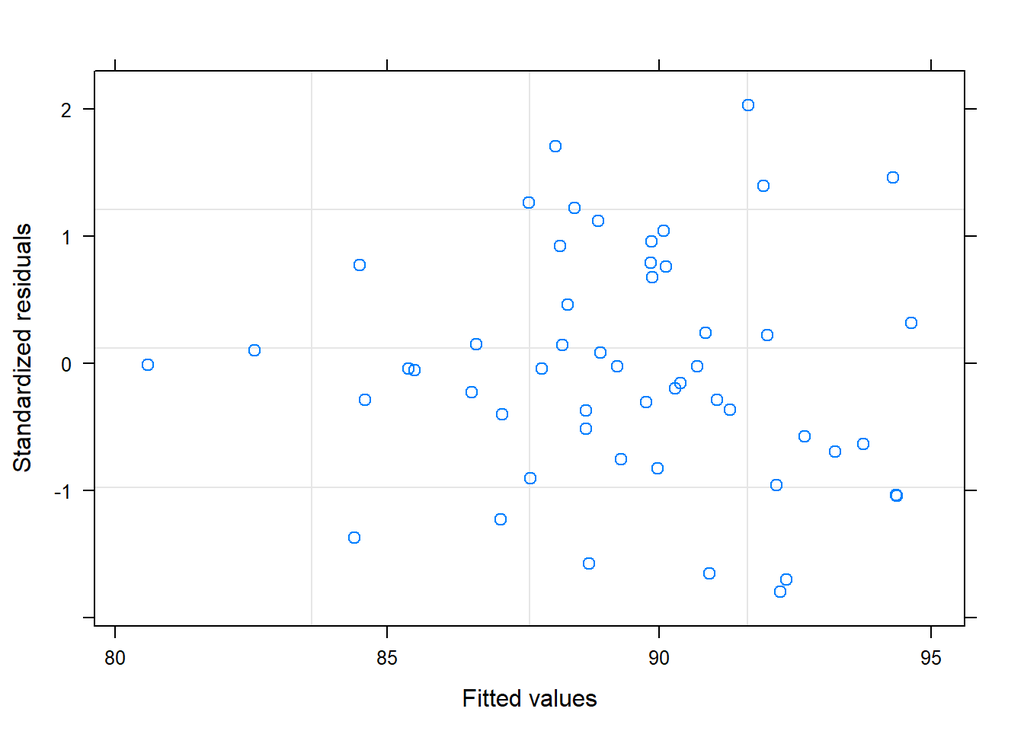

Model 4: Swap for daily max pm2.5

```
## Generalized least squares fit by REML
##   Model: SCC_avg ~ DATE + THI + FOOTHILLS_DAILYMAXO3 + PM2.5_max
##   Data: dairy_data2
##        AIC      BIC    logLik
##   374.0953 387.1937 -180.0476
##
## Correlation Structure: AR(1)
##  Formula: ~1
##  Parameter estimate(s):
##       Phi
## 0.5820167
##
## Coefficients:
##                           Value Std.Error    t-value p-value
## (Intercept)          -1427.2370 2758.5496 -0.5173867  0.6073
## DATE                     0.0833    0.1530  0.5442791  0.5888
## THI                     -0.0260    0.1534 -0.1695727  0.8661
## FOOTHILLS_DAILYMAXO3     0.2493    0.1557  1.6013478  0.1159
## PM2.5_max                0.2678    0.2284  1.1729224  0.2466
##
##  Correlation:
##                      (Intr) DATE   THI    FOOTHI
## DATE                 -1.000
## THI                   0.357 -0.358
## FOOTHILLS_DAILYMAXO3 -0.059  0.058 -0.548
## PM2.5_max            -0.183  0.183 -0.060 -0.167
##
## Standardized residuals:
##         Min          Q1         Med          Q3         Max
## -1.74902995 -0.66276258 -0.07882432  0.70398040  2.06504552
##
## Residual standard error: 8.948086
## Degrees of freedom: 53 total; 48 residual
```

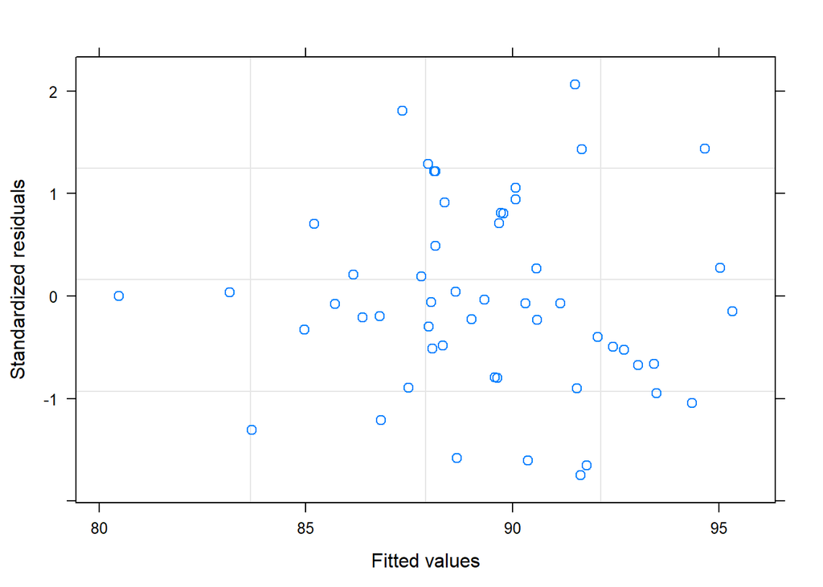